# examples_0401

Which of the following graphs matches $y=p(x)$?

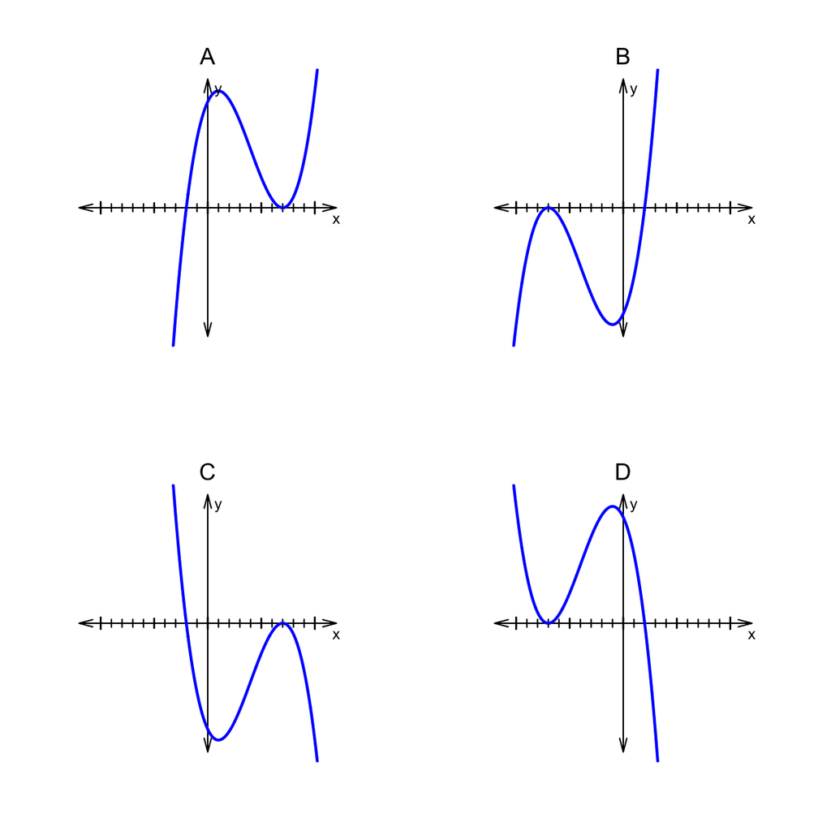

ABCD

First, consider the end behavior. If you expanded the polynomial into standard form, the highest-degree term would be $-x^{3}$.

$$p(x)~=~-x^{3}+\ldots$$

The highest degree term has a negative coefficient and an odd degree, so the end behavior is **"up,down"**. Or, more formally, $\lim\limits_{x\to-\infty} p(x) ~=~ \infty$ and $\lim\limits_{x\to\infty} p(x) ~=~ -\infty$.

Next, we consider the roots. From the factored form, $p(x)~=~-(x+2)\cdot (x-7)^{2}$, it is easy to see (see [zero-product property](https://en.wikipedia.org/wiki/Zero-product_property)) that $x=-2$ or $x=7$ makes the polynomial output 0.

$$p(-2)~=~-(-2+2)\cdot
(-2-7)^{2}~=~0$$
$$p(7)~=~-(7+2)\cdot
(7-7)^{2}~=~0$$

We predict that at $x=7$ there is a double root (multiplicity of 2) because the corresponding factor is squared. Graphically, we expect the curve to "bounce" off the $x$ axis at $x=7$. At the other root, we expect the curve to cut through the $x$ axis.

Anyway, based on this analysis, we can produce a [sign](https://en.wikipedia.org/wiki/Sign_function) graph of the polynomial.

| $x$ interval or value | sign analysis of $p(x)~=~-(x+2)\cdot (x-7)^{2}$ | sign |
| --- | --- | --- |
| $(-\infty,-2)$ | $-(\mathrm{neg})\cdot (\mathrm{neg})^{2}$ | $1$ |
| $-2$ | $-(\mathrm{zero})\cdot (\mathrm{neg})^{2}$ | $0$ |
| $(-2,7)$ | $-(\mathrm{pos})\cdot (\mathrm{neg})^{2}$ | $-1$ |
| $7$ | $-(\mathrm{pos})\cdot (\mathrm{zero})^{2}$ | $0$ |
| $(7,\infty)$ | $-(\mathrm{pos})\cdot (\mathrm{pos})^{2}$ | $-1$ |

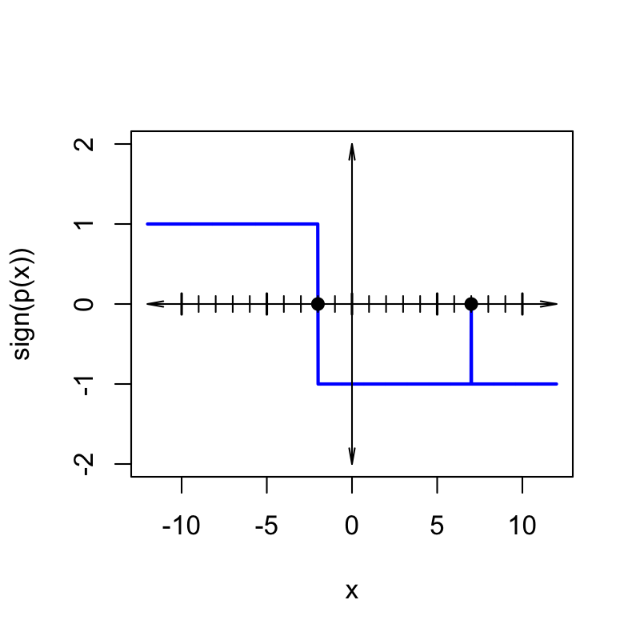

And only one option matches.

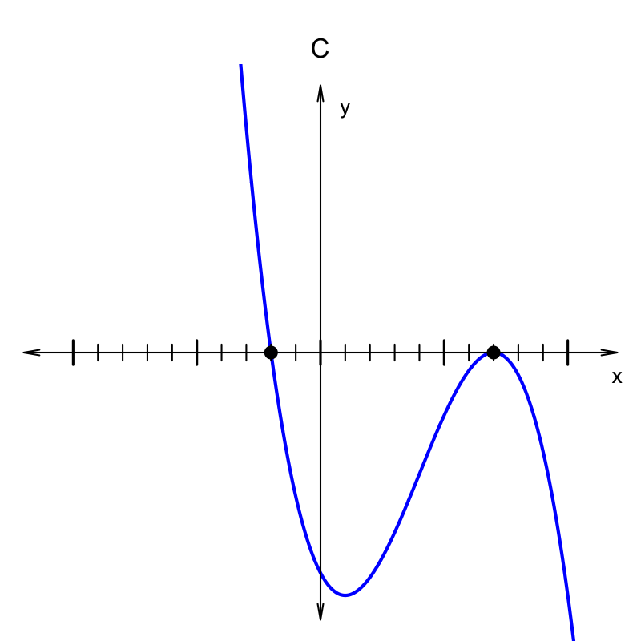

A polynomial, $p(x)$, is given in factored form.
$$p(x)~=~(x+9)^{2}\cdot
(x+6)\cdot (x+1)$$

Which of the following graphs matches $y=p(x)$?

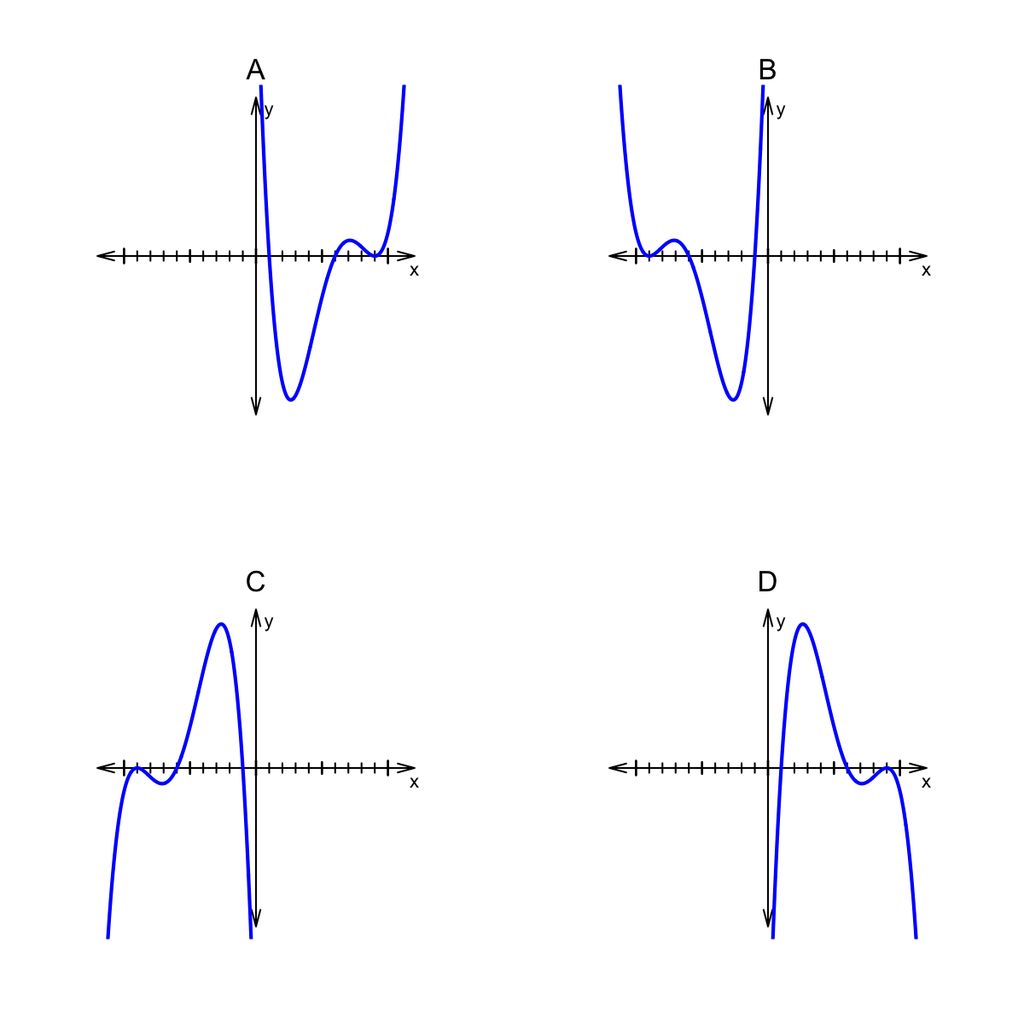

ABCD

First, consider the end behavior. If you expanded the polynomial into standard form, the highest-degree term would be $x^{4}$.

$$p(x)~=~x^{4}+\ldots$$

The highest degree term has a positive coefficient and an even degree, so the end behavior is **"up,up"**. Or, more formally, $\lim\limits_{x\to-\infty} p(x) ~=~ \infty$ and $\lim\limits_{x\to\infty} p(x) ~=~ \infty$.

Next, we consider the roots. From the factored form, $p(x)~=~(x+9)^{2}\cdot (x+6)\cdot (x+1)$, it is easy to see (see [zero-product property](https://en.wikipedia.org/wiki/Zero-product_property)) that $x=-9$ or $x=-6$ or $x=-1$ makes the polynomial output 0.

$$p(-9)~=~(-9+9)^{2}\cdot (-9+6)\cdot
(-9+1)~=~0$$
$$p(-6)~=~(-6+9)^{2}\cdot
(-6+6)\cdot (-6+1)~=~0$$
$$p(-1)~=~(-1+9)^{2}\cdot (-1+6)\cdot
(-1+1)~=~0$$

We predict that at $x=-9$ there is a double root (multiplicity of 2) because the corresponding factor is squared. Graphically, we expect the curve to "bounce" off the $x$ axis at $x=-9$. At the other roots, we expect the curve to cut through the $x$ axis.

Anyway, based on this analysis, we can produce a [sign](https://en.wikipedia.org/wiki/Sign_function) graph of the polynomial.

| $x$ interval or value | sign analysis of $p(x)~=~(x+9)^{2}\cdot (x+6)\cdot (x+1)$ | sign |
| --- | --- | --- |
| $(-\infty,-9)$ | $(\mathrm{neg})^{2}\cdot (\mathrm{neg})\cdot (\mathrm{neg})$ | $1$ |
| $-9$ | $(\mathrm{zero})^{2}\cdot (\mathrm{neg})\cdot (\mathrm{neg})$ | $0$ |
| $(-9,-6)$ | $(\mathrm{pos})^{2}\cdot (\mathrm{neg})\cdot (\mathrm{neg})$ | $1$ |
| $-6$ | $(\mathrm{pos})^{2}\cdot (\mathrm{zero})\cdot (\mathrm{neg})$ | $0$ |
| $(-6,-1)$ | $(\mathrm{pos})^{2}\cdot (\mathrm{pos})\cdot (\mathrm{neg})$ | $-1$ |
| $-1$ | $(\mathrm{pos})^{2}\cdot (\mathrm{pos})\cdot (\mathrm{zero})$ | $0$ |
| $(-1,\infty)$ | $(\mathrm{pos})^{2}\cdot (\mathrm{pos})\cdot (\mathrm{pos})$ | $1$ |

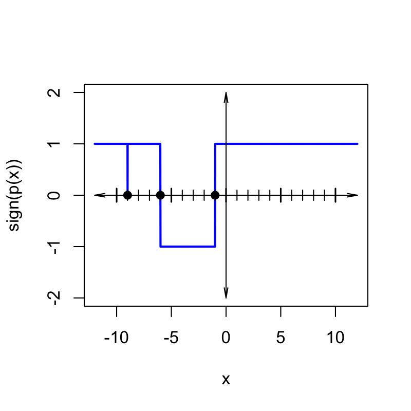

And only one option matches.

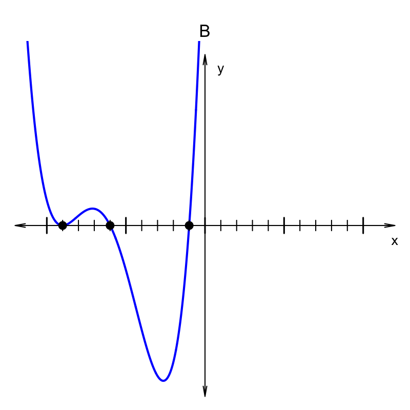

A polynomial is sketched below.

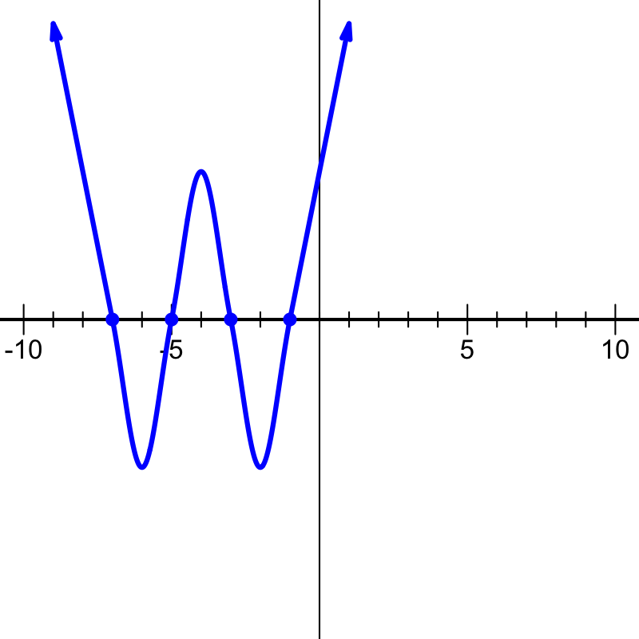

Which polynomial (in standard form) best matches the sketch?

$y=-x^4-16x^3+86x^2-176x+105$$y=x^4-16x^3+86x^2-176x+105$$y=-x^4+16x^3+86x^2+176x+105$$y=x^4+16x^3+86x^2+176x+105$

If a polynomial has a factor of $(x-r)$, then there will be an $x$-intercept at $(r,0)$.

In this case, the roots (the $x$-intercepts) are at:

$$-7,\,-5,\,-3,\,-1$$

Thus, the factors are $x+7$ and $x+5$ and $x+3$ and $x+1$. So, we know that the function could be written as:

$$y=a(x+7)(x+5)(x+3)(x+1)$$

where $a$ is some constant.

Lastly, we need to determine whether $a$ should be positive or negative. In this problem, either $a=1$ or $a=-1$. To determine this, look at the right side of the graph. Specifically, we are considering the [end behavior of polynomials](https://www.khanacademy.org/math/algebra2/x2ec2f6f830c9fb89:poly-graphs/x2ec2f6f830c9fb89:poly-end-behavior/a/end-behavior-of-polynomials). Notice that once $x$ is larger than $-1$, all the factors will be positive, so only $a$ will dictate whether the function on the right side is positive or negative.

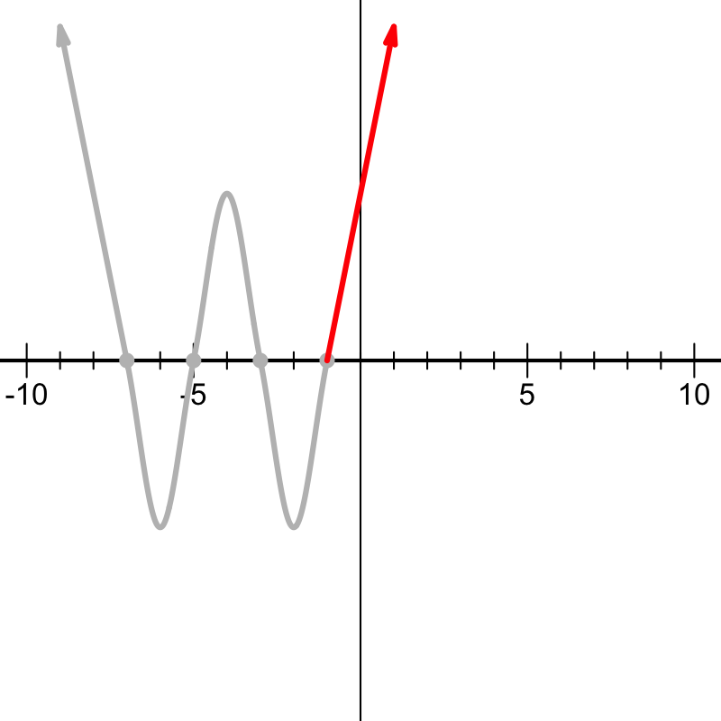

Notice, on the right side, the function is heading up. I guess more importantly, as $x\to \infty$ we see the function is positive. This implies that $a$ is positive. So, in this case, $a=1$.

$$y=(x+7)(x+5)(x+3)(x+1)$$

Then, we need to **EXPAND** into standard form. You can do this with repeated box multiplication. You can also use this identity:

$$\begin{align*}
(x+a)(x+b)(x+c)(x+d) \equiv & ~ x^4 \\
& + (a+b+c+d)x^3 \\
& + (ab+ac+ad+bc+bd+cd)x^2 \\
& + (abc+abd+acd+bcd)x \\
& + abcd
\end{align*}$$

And so, the answer is $y=x^4+16x^3+86x^2+176x+105$.

A polynomial is sketched below.

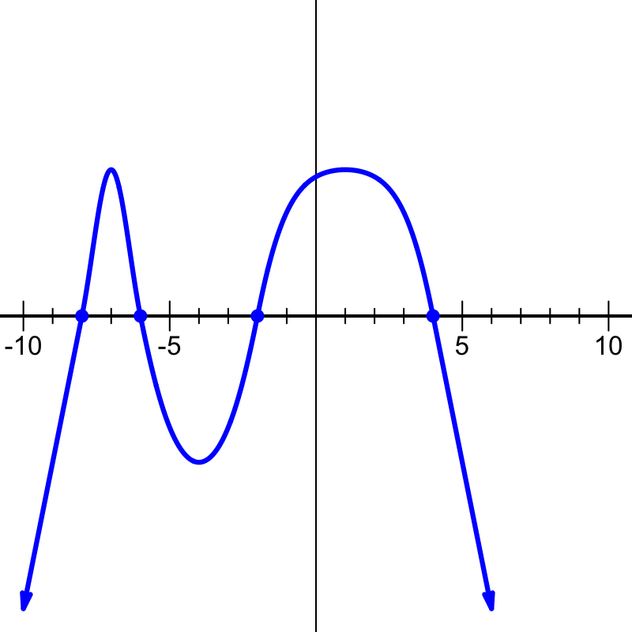

Which polynomial (in standard form) best matches the sketch?

$y=x^4-12x^3+12x^2+208x-384$$y=x^4+12x^3+12x^2-208x-384$$y=-x^4-12x^3+12x^2+208x-384$$y=-x^4+12x^3+12x^2-208x-384$

If a polynomial has a factor of $(x-r)$, then there will be an $x$-intercept at $(r,0)$.

In this case, the roots (the $x$-intercepts) are at:

$$-8,\,-6,\,-2,\,4$$

Thus, the factors are $x+8$ and $x+6$ and $x+2$ and $x-4$. So, we know that the function could be written as:

$$y=a(x+8)(x+6)(x+2)(x-4)$$

where $a$ is some constant.

Lastly, we need to determine whether $a$ should be positive or negative. In this problem, either $a=1$ or $a=-1$. To determine this, look at the right side of the graph. Specifically, we are considering the [end behavior of polynomials](https://www.khanacademy.org/math/algebra2/x2ec2f6f830c9fb89:poly-graphs/x2ec2f6f830c9fb89:poly-end-behavior/a/end-behavior-of-polynomials). Notice that once $x$ is larger than $4$, all the factors will be positive, so only $a$ will dictate whether the function on the right side is positive or negative.

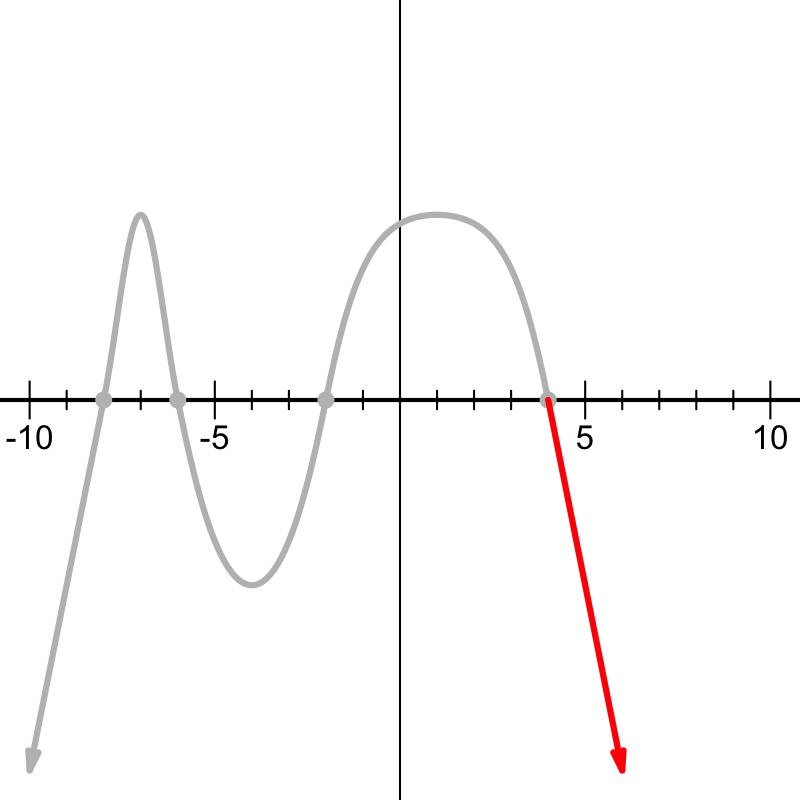

Notice, on the right side, the function is heading down. I guess more importantly, as $x\to \infty$ we see the function is negative. This implies that $a$ is negative. So, in this case, $a=-1$.

$$y=-(x+8)(x+6)(x+2)(x-4)$$

Then, we need to **EXPAND** into standard form. You can do this with repeated box multiplication. You can also use this identity:

$$\begin{align*}
(x+a)(x+b)(x+c)(x+d) \equiv & ~ x^4 \\
& + (a+b+c+d)x^3 \\
& + (ab+ac+ad+bc+bd+cd)x^2 \\
& + (abc+abd+acd+bcd)x \\
& + abcd
\end{align*}$$

And so, the answer is $y=-x^4+12x^3+12x^2-208x-384$.

A polynomial is sketched below.

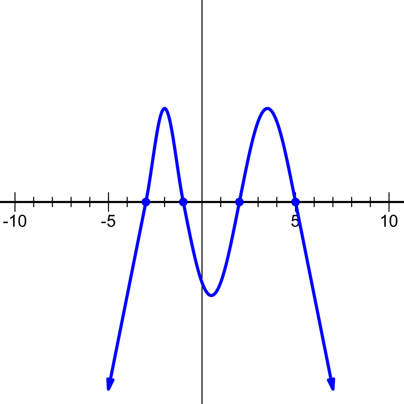

Which polynomial (in standard form) best matches the sketch?

$y=x^4-3x^3-15x^2+19x+30$$y=-x^4-3x^3-15x^2+19x+30$$y=x^4+3x^3-15x^2-19x+30$$y=-x^4+3x^3-15x^2-19x+30$

If a polynomial has a factor of $(x-r)$, then there will be an $x$-intercept at $(r,0)$.

In this case, the roots (the $x$-intercepts) are at:

$$-3,\,-1,\,2,\,5$$

Thus, the factors are $x+3$ and $x+1$ and $x-2$ and $x-5$. So, we know that the function could be written as:

$$y=a(x+3)(x+1)(x-2)(x-5)$$

where $a$ is some constant.

Lastly, we need to determine whether $a$ should be positive or negative. In this problem, either $a=1$ or $a=-1$. To determine this, look at the right side of the graph. Specifically, we are considering the [end behavior of polynomials](https://www.khanacademy.org/math/algebra2/x2ec2f6f830c9fb89:poly-graphs/x2ec2f6f830c9fb89:poly-end-behavior/a/end-behavior-of-polynomials). Notice that once $x$ is larger than $5$, all the factors will be positive, so only $a$ will dictate whether the function on the right side is positive or negative.

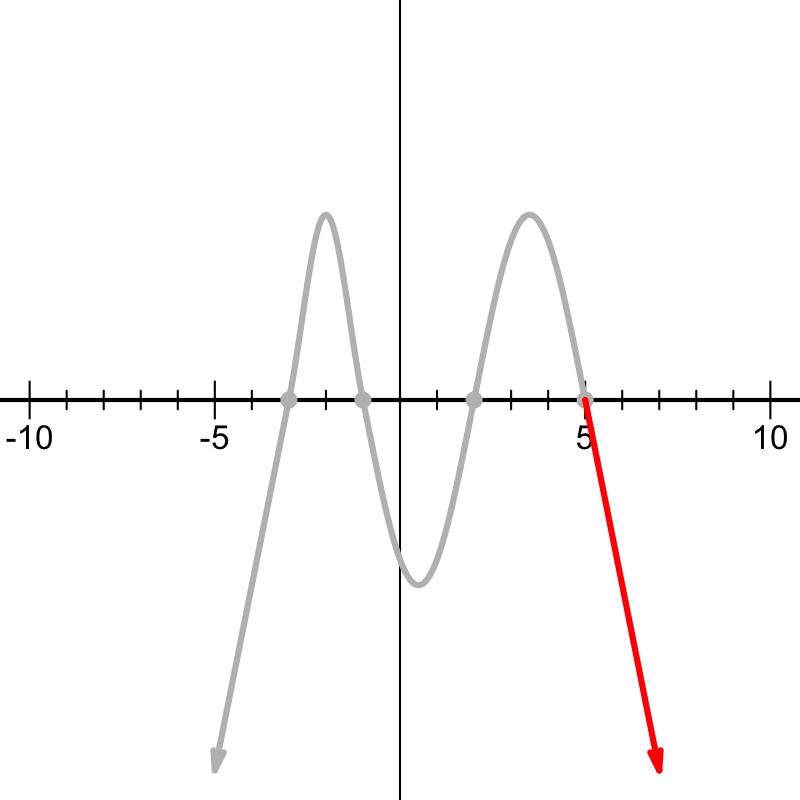

Notice, on the right side, the function is heading down. I guess more importantly, as $x\to \infty$ we see the function is negative. This implies that $a$ is negative. So, in this case, $a=-1$.

$$y=-(x+3)(x+1)(x-2)(x-5)$$

Then, we need to **EXPAND** into standard form. You can do this with repeated box multiplication. You can also use this identity:

$$\begin{align*}
(x+a)(x+b)(x+c)(x+d) \equiv & ~ x^4 \\
& + (a+b+c+d)x^3 \\
& + (ab+ac+ad+bc+bd+cd)x^2 \\
& + (abc+abd+acd+bcd)x \\
& + abcd
\end{align*}$$

And so, the answer is $y=-x^4-3x^3-15x^2+19x+30$.

A polynomial is sketched below.

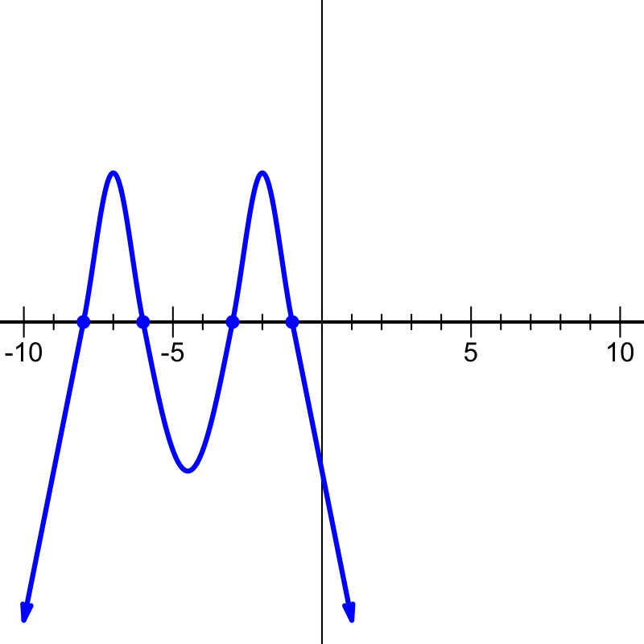

Which polynomial (in standard form) best matches the sketch?

$y=x^4-18x^3+107x^2-234x+144$$y=x^4+18x^3+107x^2+234x+144$$y=-x^4+18x^3+107x^2+234x+144$$y=-x^4-18x^3+107x^2-234x+144$

If a polynomial has a factor of $(x-r)$, then there will be an $x$-intercept at $(r,0)$.

In this case, the roots (the $x$-intercepts) are at:

$$-8,\,-6,\,-3,\,-1$$

Thus, the factors are $x+8$ and $x+6$ and $x+3$ and $x+1$. So, we know that the function could be written as:

$$y=a(x+8)(x+6)(x+3)(x+1)$$

where $a$ is some constant.

Lastly, we need to determine whether $a$ should be positive or negative. In this problem, either $a=1$ or $a=-1$. To determine this, look at the right side of the graph. Specifically, we are considering the [end behavior of polynomials](https://www.khanacademy.org/math/algebra2/x2ec2f6f830c9fb89:poly-graphs/x2ec2f6f830c9fb89:poly-end-behavior/a/end-behavior-of-polynomials). Notice that once $x$ is larger than $-1$, all the factors will be positive, so only $a$ will dictate whether the function on the right side is positive or negative.

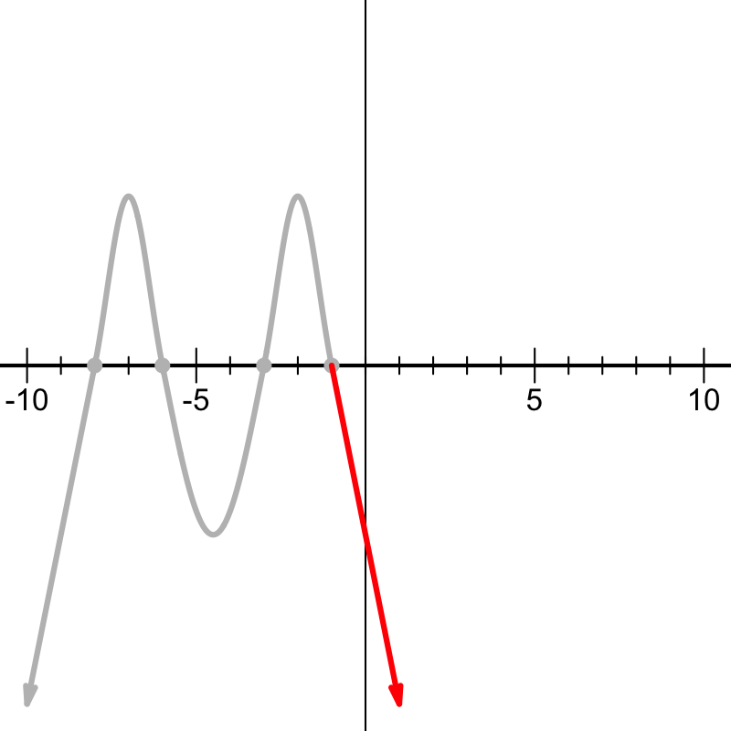

Notice, on the right side, the function is heading down. I guess more importantly, as $x\to \infty$ we see the function is negative. This implies that $a$ is negative. So, in this case, $a=-1$.

$$y=-(x+8)(x+6)(x+3)(x+1)$$

Then, we need to **EXPAND** into standard form. You can do this with repeated box multiplication. You can also use this identity:

$$\begin{align*}
(x+a)(x+b)(x+c)(x+d) \equiv & ~ x^4 \\
& + (a+b+c+d)x^3 \\
& + (ab+ac+ad+bc+bd+cd)x^2 \\
& + (abc+abd+acd+bcd)x \\
& + abcd
\end{align*}$$

And so, the answer is $y=-x^4+18x^3+107x^2+234x+144$.

A polynomial is sketched below.

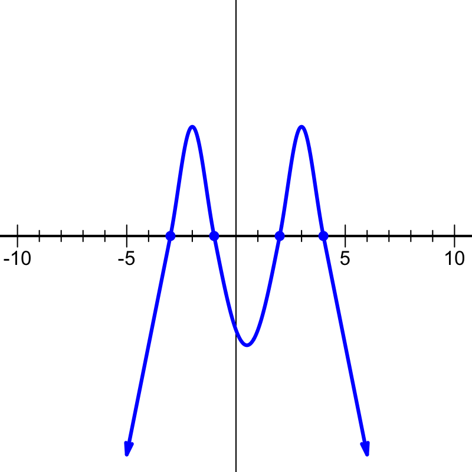

Which polynomial (in standard form) best matches the sketch?

$y=-x^4+2x^3-13x^2-14x+24$$y=x^4+2x^3-13x^2-14x+24$$y=-x^4-2x^3-13x^2+14x+24$$y=x^4-2x^3-13x^2+14x+24$

If a polynomial has a factor of $(x-r)$, then there will be an $x$-intercept at $(r,0)$.

In this case, the roots (the $x$-intercepts) are at:

$$-3,\,-1,\,2,\,4$$

Thus, the factors are $x+3$ and $x+1$ and $x-2$ and $x-4$. So, we know that the function could be written as:

$$y=a(x+3)(x+1)(x-2)(x-4)$$

where $a$ is some constant.

Lastly, we need to determine whether $a$ should be positive or negative. In this problem, either $a=1$ or $a=-1$. To determine this, look at the right side of the graph. Specifically, we are considering the [end behavior of polynomials](https://www.khanacademy.org/math/algebra2/x2ec2f6f830c9fb89:poly-graphs/x2ec2f6f830c9fb89:poly-end-behavior/a/end-behavior-of-polynomials). Notice that once $x$ is larger than $4$, all the factors will be positive, so only $a$ will dictate whether the function on the right side is positive or negative.

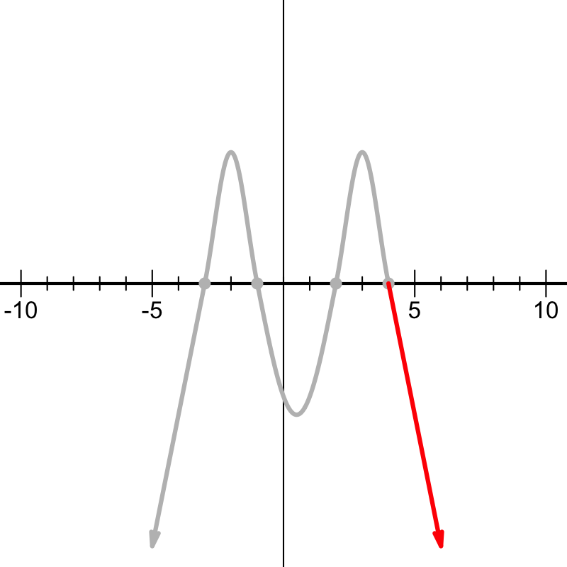

Notice, on the right side, the function is heading down. I guess more importantly, as $x\to \infty$ we see the function is negative. This implies that $a$ is negative. So, in this case, $a=-1$.

$$y=-(x+3)(x+1)(x-2)(x-4)$$

Then, we need to **EXPAND** into standard form. You can do this with repeated box multiplication. You can also use this identity:

$$\begin{align*}
(x+a)(x+b)(x+c)(x+d) \equiv & ~ x^4 \\
& + (a+b+c+d)x^3 \\
& + (ab+ac+ad+bc+bd+cd)x^2 \\
& + (abc+abd+acd+bcd)x \\
& + abcd
\end{align*}$$

And so, the answer is $y=-x^4-2x^3-13x^2+14x+24$.

A polynomial is sketched below.

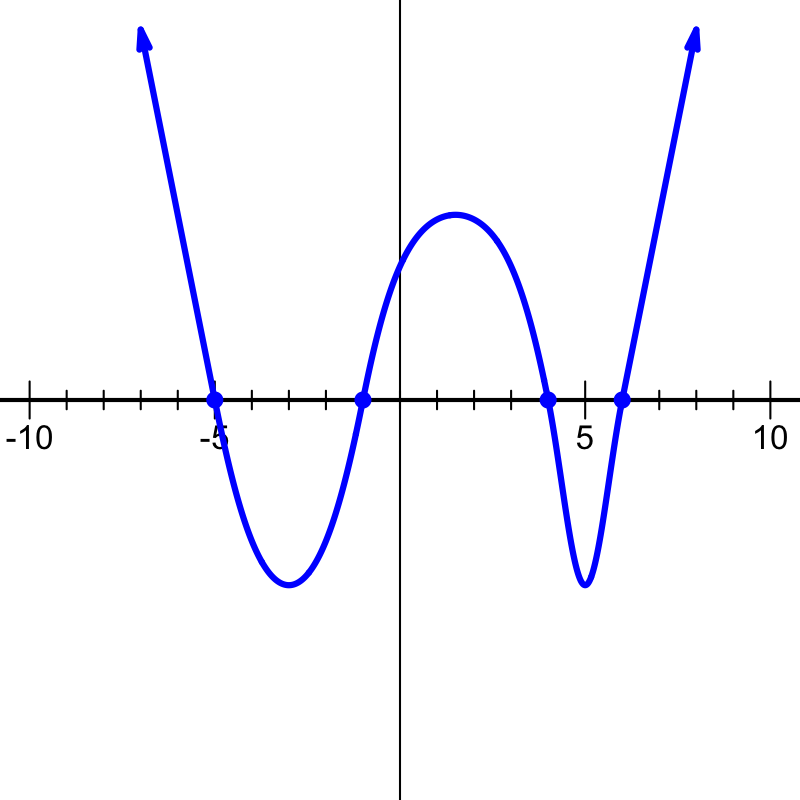

Which polynomial (in standard form) best matches the sketch?

$y=-x^4+4x^3-31x^2-94x+120$$y=x^4-4x^3-31x^2+94x+120$$y=-x^4-4x^3-31x^2+94x+120$$y=x^4+4x^3-31x^2-94x+120$

If a polynomial has a factor of $(x-r)$, then there will be an $x$-intercept at $(r,0)$.

In this case, the roots (the $x$-intercepts) are at:

$$-5,\,-1,\,4,\,6$$

Thus, the factors are $x+5$ and $x+1$ and $x-4$ and $x-6$. So, we know that the function could be written as:

$$y=a(x+5)(x+1)(x-4)(x-6)$$

where $a$ is some constant.

Lastly, we need to determine whether $a$ should be positive or negative. In this problem, either $a=1$ or $a=-1$. To determine this, look at the right side of the graph. Specifically, we are considering the [end behavior of polynomials](https://www.khanacademy.org/math/algebra2/x2ec2f6f830c9fb89:poly-graphs/x2ec2f6f830c9fb89:poly-end-behavior/a/end-behavior-of-polynomials). Notice that once $x$ is larger than $6$, all the factors will be positive, so only $a$ will dictate whether the function on the right side is positive or negative.

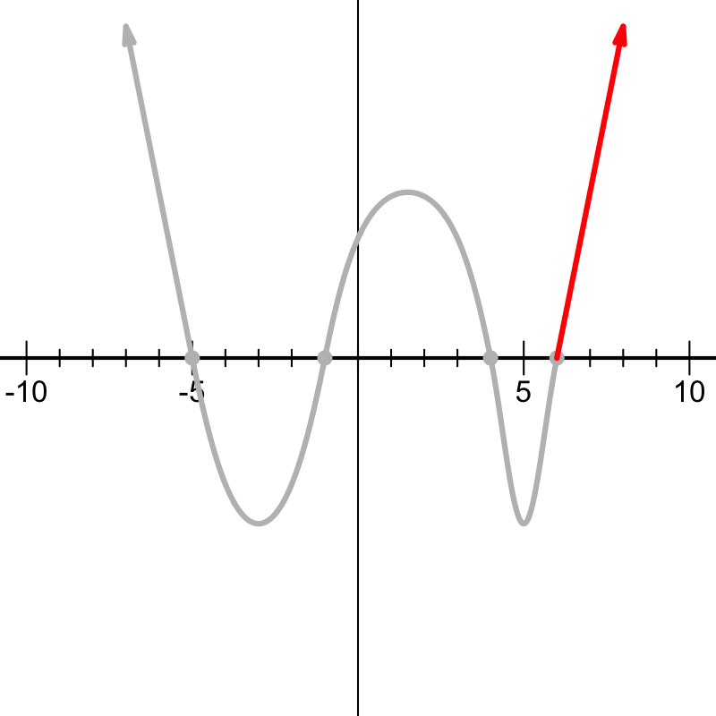

Notice, on the right side, the function is heading up. I guess more importantly, as $x\to \infty$ we see the function is positive. This implies that $a$ is positive. So, in this case, $a=1$.

$$y=(x+5)(x+1)(x-4)(x-6)$$

Then, we need to **EXPAND** into standard form. You can do this with repeated box multiplication. You can also use this identity:

$$\begin{align*}
(x+a)(x+b)(x+c)(x+d) \equiv & ~ x^4 \\
& + (a+b+c+d)x^3 \\
& + (ab+ac+ad+bc+bd+cd)x^2 \\
& + (abc+abd+acd+bcd)x \\
& + abcd
\end{align*}$$

And so, the answer is $y=x^4-4x^3-31x^2+94x+120$.

A polynomial is sketched below.

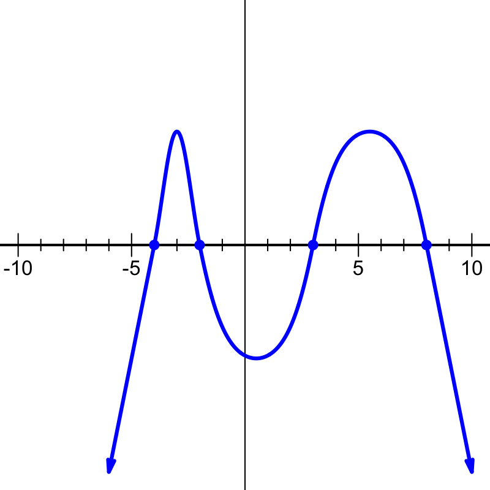

Which polynomial (in standard form) best matches the sketch?

$y=-x^4+5x^3-34x^2-56x+192$$y=x^4+5x^3-34x^2-56x+192$$y=x^4-5x^3-34x^2+56x+192$$y=-x^4-5x^3-34x^2+56x+192$

If a polynomial has a factor of $(x-r)$, then there will be an $x$-intercept at $(r,0)$.

In this case, the roots (the $x$-intercepts) are at:

$$-4,\,-2,\,3,\,8$$

Thus, the factors are $x+4$ and $x+2$ and $x-3$ and $x-8$. So, we know that the function could be written as:

$$y=a(x+4)(x+2)(x-3)(x-8)$$

where $a$ is some constant.

Lastly, we need to determine whether $a$ should be positive or negative. In this problem, either $a=1$ or $a=-1$. To determine this, look at the right side of the graph. Specifically, we are considering the [end behavior of polynomials](https://www.khanacademy.org/math/algebra2/x2ec2f6f830c9fb89:poly-graphs/x2ec2f6f830c9fb89:poly-end-behavior/a/end-behavior-of-polynomials). Notice that once $x$ is larger than $8$, all the factors will be positive, so only $a$ will dictate whether the function on the right side is positive or negative.

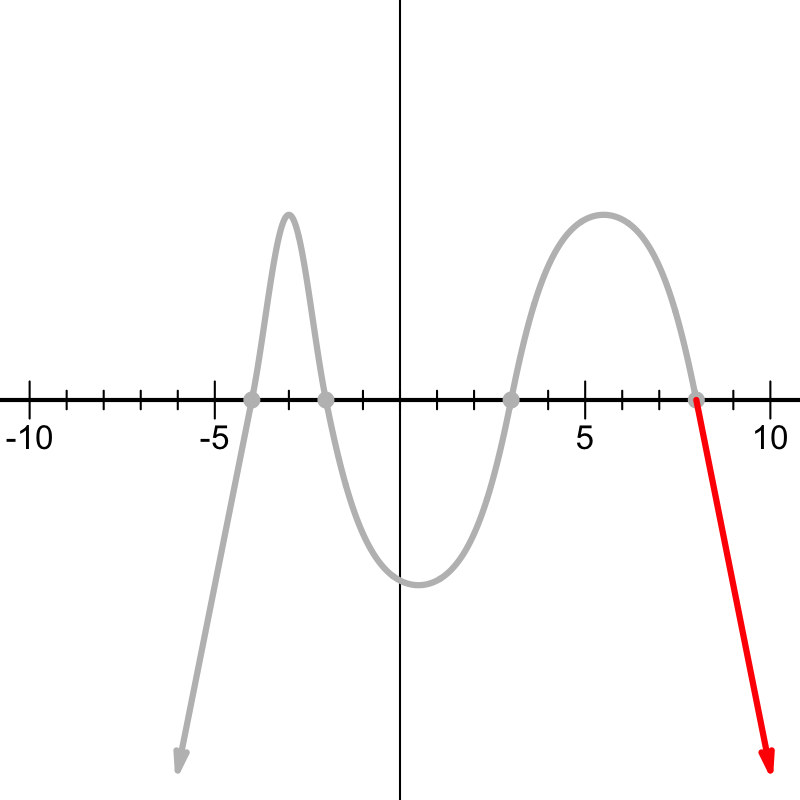

Notice, on the right side, the function is heading down. I guess more importantly, as $x\to \infty$ we see the function is negative. This implies that $a$ is negative. So, in this case, $a=-1$.

$$y=-(x+4)(x+2)(x-3)(x-8)$$

Then, we need to **EXPAND** into standard form. You can do this with repeated box multiplication. You can also use this identity:

$$\begin{align*}
(x+a)(x+b)(x+c)(x+d) \equiv & ~ x^4 \\
& + (a+b+c+d)x^3 \\
& + (ab+ac+ad+bc+bd+cd)x^2 \\
& + (abc+abd+acd+bcd)x \\
& + abcd
\end{align*}$$

And so, the answer is $y=-x^4-5x^3-34x^2+56x+192$.

A polynomial is sketched below.

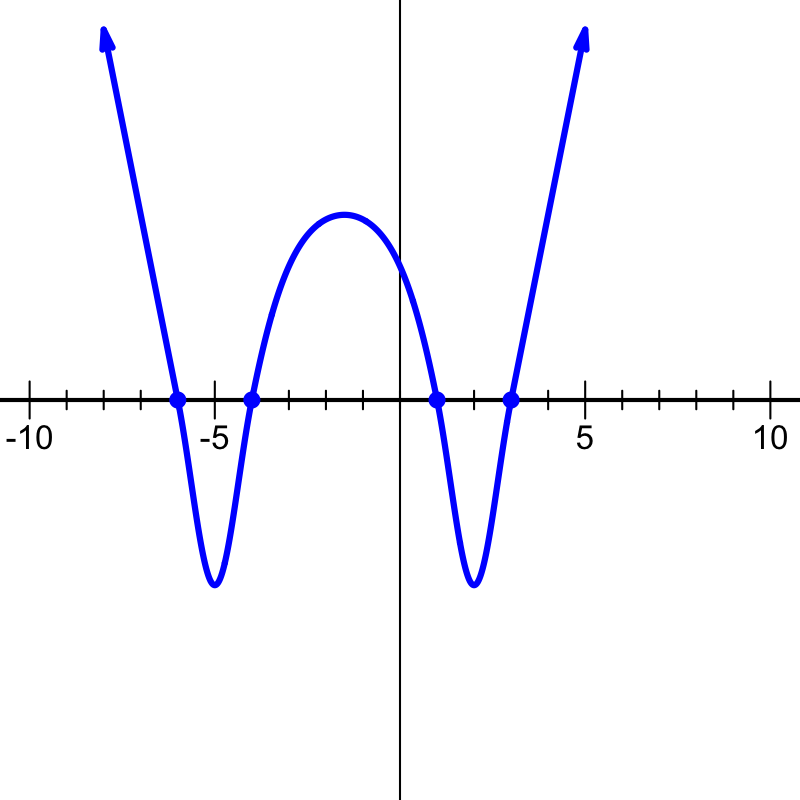

Which polynomial (in standard form) best matches the sketch?

$y=x^4-6x^3-13x^2+66x+72$$y=x^4+6x^3-13x^2-66x+72$$y=-x^4+6x^3-13x^2-66x+72$$y=-x^4-6x^3-13x^2+66x+72$

If a polynomial has a factor of $(x-r)$, then there will be an $x$-intercept at $(r,0)$.

In this case, the roots (the $x$-intercepts) are at:

$$-6,\,-4,\,1,\,3$$

Thus, the factors are $x+6$ and $x+4$ and $x-1$ and $x-3$. So, we know that the function could be written as:

$$y=a(x+6)(x+4)(x-1)(x-3)$$

where $a$ is some constant.

Lastly, we need to determine whether $a$ should be positive or negative. In this problem, either $a=1$ or $a=-1$. To determine this, look at the right side of the graph. Specifically, we are considering the [end behavior of polynomials](https://www.khanacademy.org/math/algebra2/x2ec2f6f830c9fb89:poly-graphs/x2ec2f6f830c9fb89:poly-end-behavior/a/end-behavior-of-polynomials). Notice that once $x$ is larger than $3$, all the factors will be positive, so only $a$ will dictate whether the function on the right side is positive or negative.

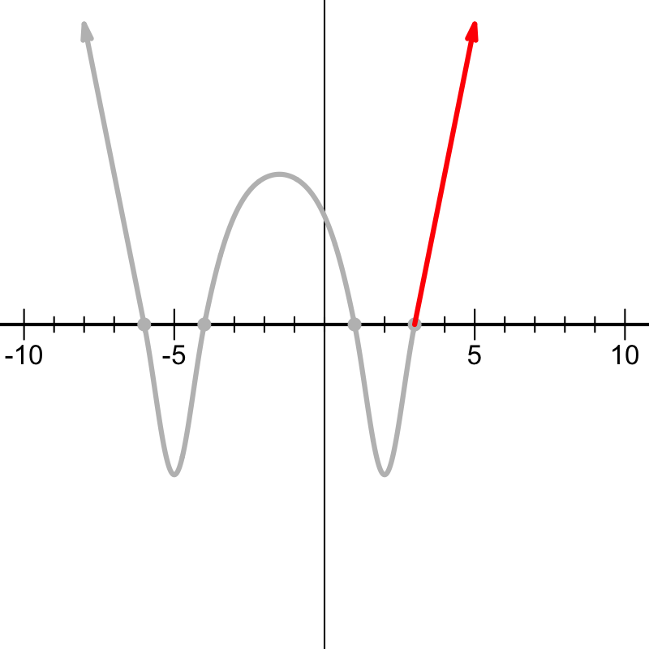

Notice, on the right side, the function is heading up. I guess more importantly, as $x\to \infty$ we see the function is positive. This implies that $a$ is positive. So, in this case, $a=1$.

$$y=(x+6)(x+4)(x-1)(x-3)$$

Then, we need to **EXPAND** into standard form. You can do this with repeated box multiplication. You can also use this identity:

$$\begin{align*}
(x+a)(x+b)(x+c)(x+d) \equiv & ~ x^4 \\
& + (a+b+c+d)x^3 \\
& + (ab+ac+ad+bc+bd+cd)x^2 \\
& + (abc+abd+acd+bcd)x \\
& + abcd
\end{align*}$$

And so, the answer is $y=x^4+6x^3-13x^2-66x+72$.

A polynomial is sketched below.

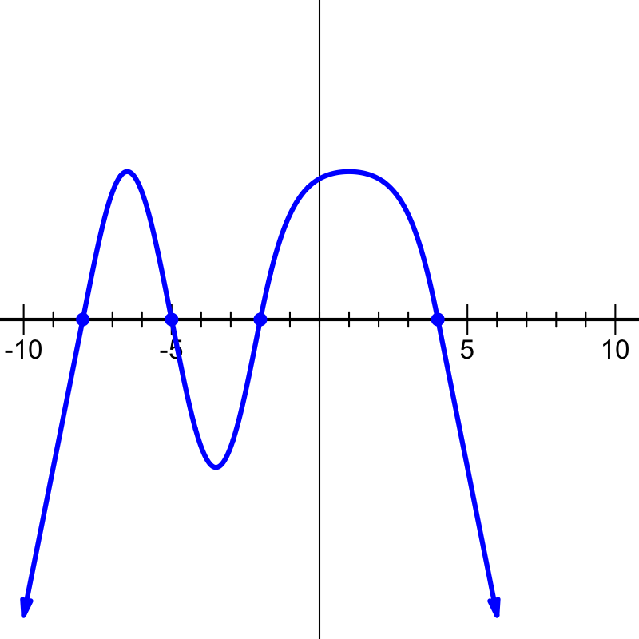

Which polynomial (in standard form) best matches the sketch?

$y=x^4+11x^3+6x^2-184x-320$$y=-x^4+11x^3+6x^2-184x-320$$y=x^4-11x^3+6x^2+184x-320$$y=-x^4-11x^3+6x^2+184x-320$

If a polynomial has a factor of $(x-r)$, then there will be an $x$-intercept at $(r,0)$.

In this case, the roots (the $x$-intercepts) are at:

$$-8,\,-5,\,-2,\,4$$

Thus, the factors are $x+8$ and $x+5$ and $x+2$ and $x-4$. So, we know that the function could be written as:

$$y=a(x+8)(x+5)(x+2)(x-4)$$

where $a$ is some constant.

Lastly, we need to determine whether $a$ should be positive or negative. In this problem, either $a=1$ or $a=-1$. To determine this, look at the right side of the graph. Specifically, we are considering the [end behavior of polynomials](https://www.khanacademy.org/math/algebra2/x2ec2f6f830c9fb89:poly-graphs/x2ec2f6f830c9fb89:poly-end-behavior/a/end-behavior-of-polynomials). Notice that once $x$ is larger than $4$, all the factors will be positive, so only $a$ will dictate whether the function on the right side is positive or negative.

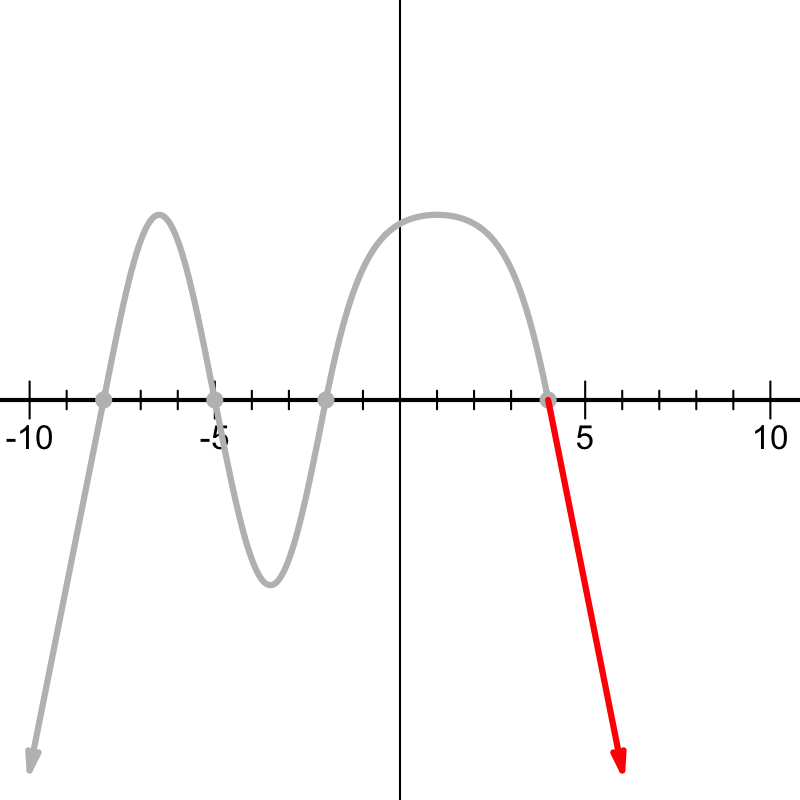

Notice, on the right side, the function is heading down. I guess more importantly, as $x\to \infty$ we see the function is negative. This implies that $a$ is negative. So, in this case, $a=-1$.

$$y=-(x+8)(x+5)(x+2)(x-4)$$

Then, we need to **EXPAND** into standard form. You can do this with repeated box multiplication. You can also use this identity:

$$\begin{align*}
(x+a)(x+b)(x+c)(x+d) \equiv & ~ x^4 \\
& + (a+b+c+d)x^3 \\
& + (ab+ac+ad+bc+bd+cd)x^2 \\
& + (abc+abd+acd+bcd)x \\
& + abcd
\end{align*}$$

And so, the answer is $y=-x^4+11x^3+6x^2-184x-320$.

A polynomial is sketched below.

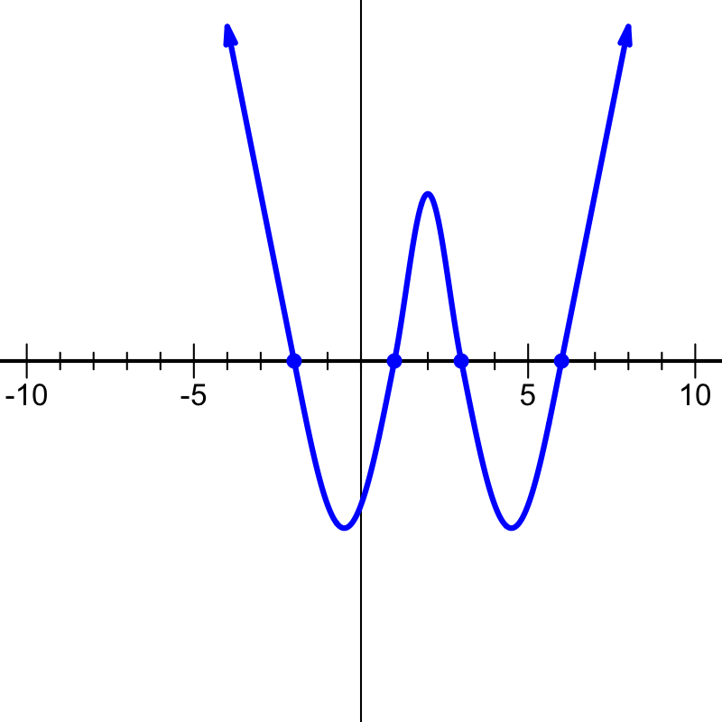

Which polynomial (in standard form) best matches the sketch?

$y=x^4+8x^3+7x^2-36x-36$$y=x^4-8x^3+7x^2+36x-36$$y=-x^4-8x^3+7x^2+36x-36$$y=-x^4+8x^3+7x^2-36x-36$

If a polynomial has a factor of $(x-r)$, then there will be an $x$-intercept at $(r,0)$.

In this case, the roots (the $x$-intercepts) are at:

$$-2,\,1,\,3,\,6$$

Thus, the factors are $x+2$ and $x-1$ and $x-3$ and $x-6$. So, we know that the function could be written as:

$$y=a(x+2)(x-1)(x-3)(x-6)$$

where $a$ is some constant.

Lastly, we need to determine whether $a$ should be positive or negative. In this problem, either $a=1$ or $a=-1$. To determine this, look at the right side of the graph. Specifically, we are considering the [end behavior of polynomials](https://www.khanacademy.org/math/algebra2/x2ec2f6f830c9fb89:poly-graphs/x2ec2f6f830c9fb89:poly-end-behavior/a/end-behavior-of-polynomials). Notice that once $x$ is larger than $6$, all the factors will be positive, so only $a$ will dictate whether the function on the right side is positive or negative.

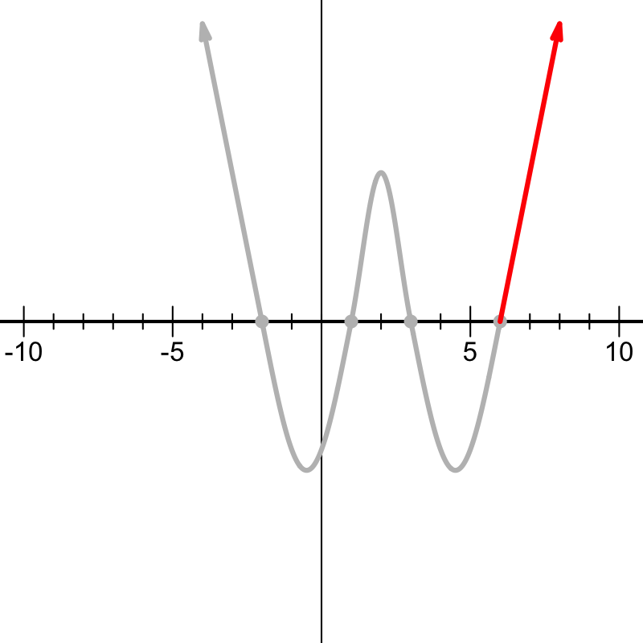

Notice, on the right side, the function is heading up. I guess more importantly, as $x\to \infty$ we see the function is positive. This implies that $a$ is positive. So, in this case, $a=1$.

$$y=(x+2)(x-1)(x-3)(x-6)$$

Then, we need to **EXPAND** into standard form. You can do this with repeated box multiplication. You can also use this identity:

$$\begin{align*}
(x+a)(x+b)(x+c)(x+d) \equiv & ~ x^4 \\
& + (a+b+c+d)x^3 \\
& + (ab+ac+ad+bc+bd+cd)x^2 \\
& + (abc+abd+acd+bcd)x \\
& + abcd
\end{align*}$$

And so, the answer is $y=x^4-8x^3+7x^2+36x-36$.

A polynomial is sketched below.

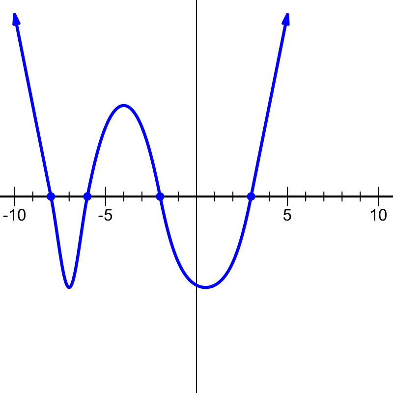

Which polynomial (in standard form) best matches the sketch?

$y=-x^4-13x^3+28x^2+132x-288$$y=-x^4+13x^3+28x^2-132x-288$$y=x^4-13x^3+28x^2+132x-288$$y=x^4+13x^3+28x^2-132x-288$

If a polynomial has a factor of $(x-r)$, then there will be an $x$-intercept at $(r,0)$.

In this case, the roots (the $x$-intercepts) are at:

$$-8,\,-6,\,-2,\,3$$

Thus, the factors are $x+8$ and $x+6$ and $x+2$ and $x-3$. So, we know that the function could be written as:

$$y=a(x+8)(x+6)(x+2)(x-3)$$

where $a$ is some constant.

Lastly, we need to determine whether $a$ should be positive or negative. In this problem, either $a=1$ or $a=-1$. To determine this, look at the right side of the graph. Specifically, we are considering the [end behavior of polynomials](https://www.khanacademy.org/math/algebra2/x2ec2f6f830c9fb89:poly-graphs/x2ec2f6f830c9fb89:poly-end-behavior/a/end-behavior-of-polynomials). Notice that once $x$ is larger than $3$, all the factors will be positive, so only $a$ will dictate whether the function on the right side is positive or negative.

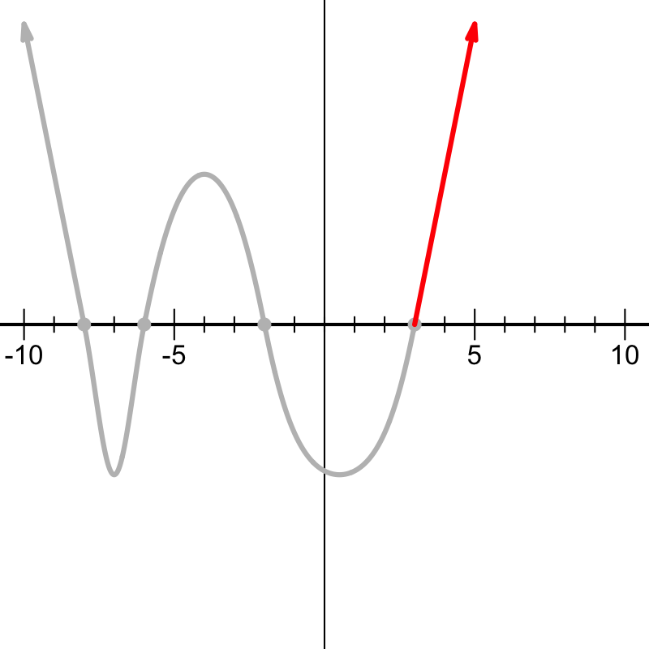

Notice, on the right side, the function is heading up. I guess more importantly, as $x\to \infty$ we see the function is positive. This implies that $a$ is positive. So, in this case, $a=1$.

$$y=(x+8)(x+6)(x+2)(x-3)$$

Then, we need to **EXPAND** into standard form. You can do this with repeated box multiplication. You can also use this identity:

$$\begin{align*}
(x+a)(x+b)(x+c)(x+d) \equiv & ~ x^4 \\
& + (a+b+c+d)x^3 \\
& + (ab+ac+ad+bc+bd+cd)x^2 \\
& + (abc+abd+acd+bcd)x \\
& + abcd
\end{align*}$$

And so, the answer is $y=x^4+13x^3+28x^2-132x-288$.

A polynomial is sketched below.

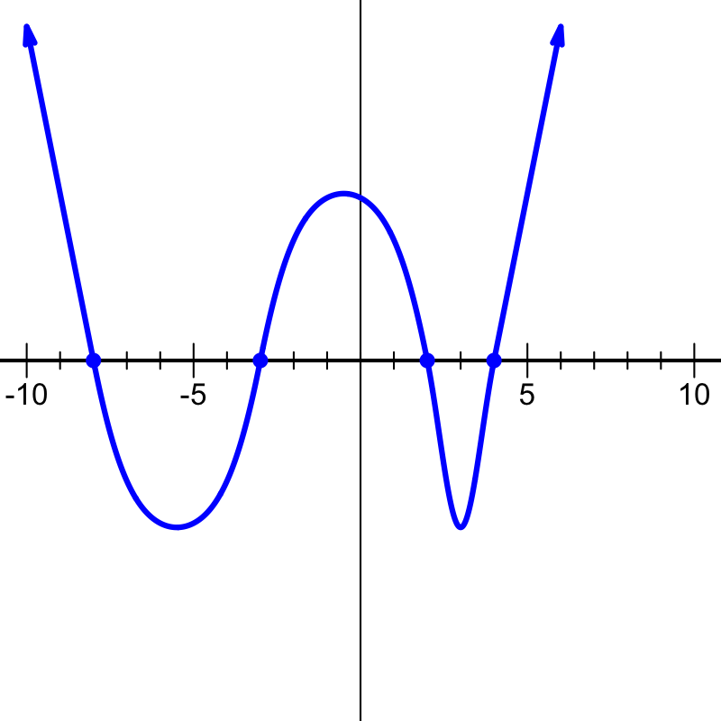

Which polynomial (in standard form) best matches the sketch?

$y=x^4-5x^3-34x^2+56x+192$$y=x^4+5x^3-34x^2-56x+192$$y=-x^4+5x^3-34x^2-56x+192$$y=-x^4-5x^3-34x^2+56x+192$

If a polynomial has a factor of $(x-r)$, then there will be an $x$-intercept at $(r,0)$.

In this case, the roots (the $x$-intercepts) are at:

$$-8,\,-3,\,2,\,4$$

Thus, the factors are $x+8$ and $x+3$ and $x-2$ and $x-4$. So, we know that the function could be written as:

$$y=a(x+8)(x+3)(x-2)(x-4)$$

where $a$ is some constant.

Lastly, we need to determine whether $a$ should be positive or negative. In this problem, either $a=1$ or $a=-1$. To determine this, look at the right side of the graph. Specifically, we are considering the [end behavior of polynomials](https://www.khanacademy.org/math/algebra2/x2ec2f6f830c9fb89:poly-graphs/x2ec2f6f830c9fb89:poly-end-behavior/a/end-behavior-of-polynomials). Notice that once $x$ is larger than $4$, all the factors will be positive, so only $a$ will dictate whether the function on the right side is positive or negative.

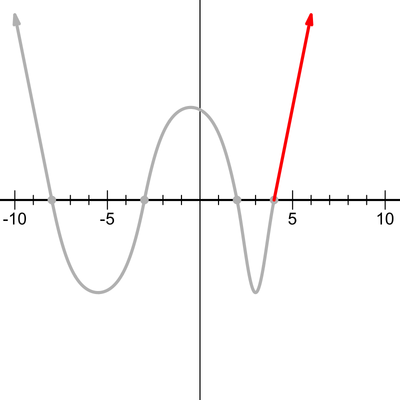

Notice, on the right side, the function is heading up. I guess more importantly, as $x\to \infty$ we see the function is positive. This implies that $a$ is positive. So, in this case, $a=1$.

$$y=(x+8)(x+3)(x-2)(x-4)$$

Then, we need to **EXPAND** into standard form. You can do this with repeated box multiplication. You can also use this identity:

$$\begin{align*}
(x+a)(x+b)(x+c)(x+d) \equiv & ~ x^4 \\
& + (a+b+c+d)x^3 \\
& + (ab+ac+ad+bc+bd+cd)x^2 \\
& + (abc+abd+acd+bcd)x \\
& + abcd
\end{align*}$$

And so, the answer is $y=x^4+5x^3-34x^2-56x+192$.